# Phuket Marathon - June 2016

Pierre Baudin

April 26, 2017

## Introduction

As part of an assignment for the Data Science Specialization offered on Coursera by the Johns Hopkins University, I decided to practice the leaflet package on my marathon data from June 2016.

GPS data and race metrics have been recorded using a Garmin Forerunner 220. The data have been downloaded from the Garmin connect website.

## Import and clean

```r
# Import the GPS coordinate of the race (format in gpx)
racetrack <- readOGR("activity_1198615565.gpx", layer = "tracks")
# Import the race split data
racedf <- read.csv("activity_1198615565.csv")

# Remove last line of summary data
racedf <- racedf[-nrow(racedf), ]

# To keep things managable, only select the split number,
# Average pace, average HR and the running cadence

racedf <- racedf %>%
        select(Split, Avg.Pace, Avg.HR, Avg.Run.Cadence) %>%
        droplevels()

racedf$Split <- ordered(racedf$Split, levels(as.factor(1:43)))
# Output a summary of the data
summary(racedf)
```

```
##      Split         Avg.Pace      Avg.HR    Avg.Run.Cadence
##  1      : 1   0:05:36  : 2   Min.   :140   Min.   : 65.69
##  2      : 1   0:05:38  : 2   1st Qu.:155   1st Qu.:140.28
##  3      : 1   0:05:40  : 2   Median :163   Median :170.03
##  4      : 1   0:05:41  : 2   Mean   :161   Mean   :157.60
##  5      : 1   0:05:45  : 2   3rd Qu.:167   3rd Qu.:172.78
##  6      : 1   0:05:49  : 2   Max.   :173   Max.   :174.45
##  (Other):37   (Other)  :31
```

```r
# Extracting the GPS information

# Big thanks to R.blogger
# I found this great article to easily extract the info from the gpx file.
# There is much more: https://www.r-bloggers.com/stay-on-track-plotting-gps-tracks-with-r/

# Parse the GPX file
pfile <- htmlTreeParse("activity_1198615565.gpx",
                        error = function(...) {}, useInternalNodes = T)
# Get all elevations, times and coordinates via the respective xpath
elevations <- as.numeric(xpathSApply(pfile, path = "//trkpt/ele", xmlValue))

times <- xpathSApply(pfile, path = "//trkpt/time", xmlValue)

coords <- xpathSApply(pfile, path = "//trkpt", xmlAttrs)
# Extract latitude and longitude from the coordinates
lats <- as.numeric(coords["lat",])
lons <- as.numeric(coords["lon",])
# Put everything in a dataframe and get rid of old variables
geodf <- data.frame(lat = lats, lon = lons, ele = elevations, time = times)
rm(list = c("elevations", "lats", "lons", "pfile", "times", "coords"))

geodf$time <- strptime(geodf$time, format = "%Y-%m-%dT%H:%M:%OS")
```

## Ploting the course

```r
m <- leaflet() %>%
        addTiles()  # Add default OpenStreetMap map tiles

# start point
m %>% addPolylines(data = racetrack, color = "red", weight = 4) %>%
                addMarkers(lng = geodf$lon[1], lat = geodf$lat[1],
                           popup = "Run Paradise - Starting and Finish line")
```

[interactive chart not shown]

## Race splits and performance

### Elevation through the race

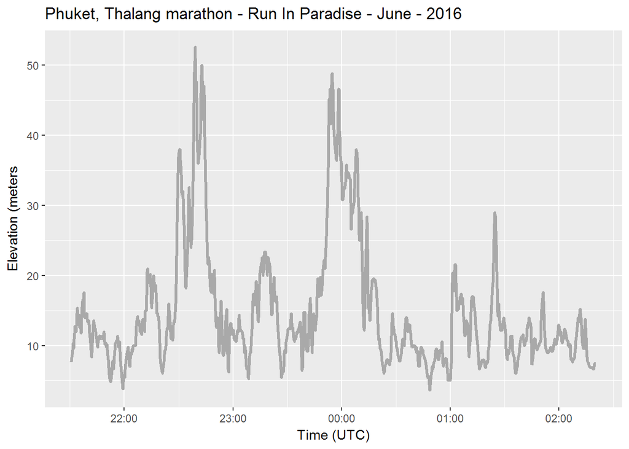

The elevation data extracted from the GPS measurement shows a difficult race with two major climb and few minor hills.

### Race measurement plots

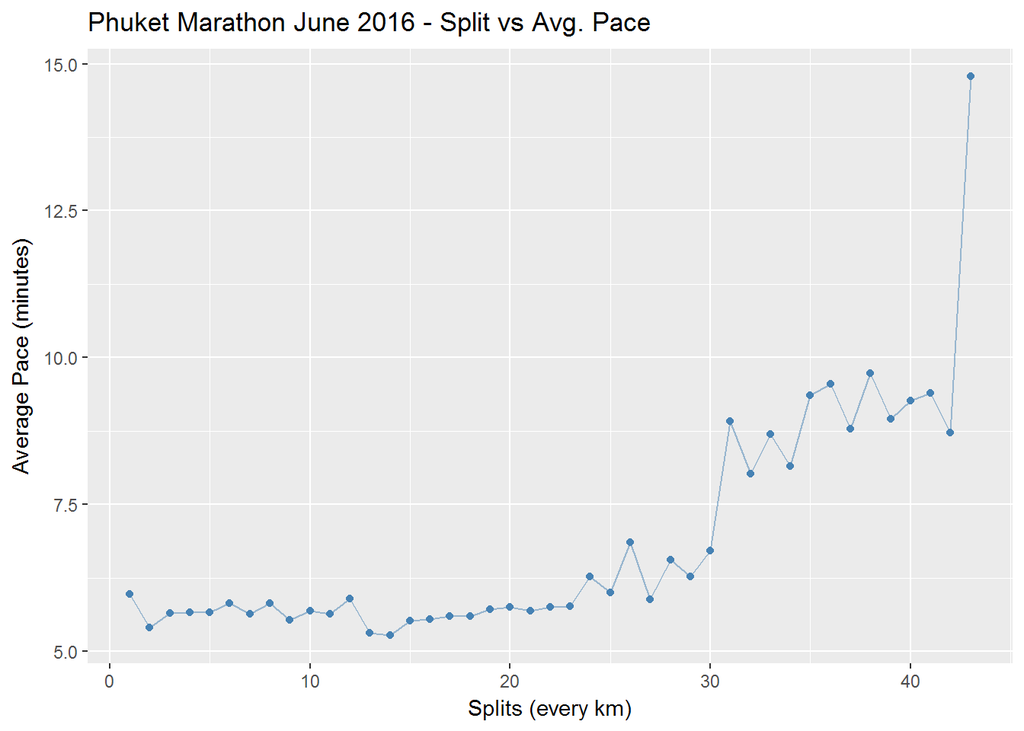

This first graph shows that the race went well until approximately the 27th kilometers. Interestingly this is a great example of what *hitting the wall* does to race performance.

My body just ran out of fuel and after the 30th kilomter, I was simply walking at a pace of about 10min/km.

To further understand what happened during the race, here is what happened to the average heart rate:

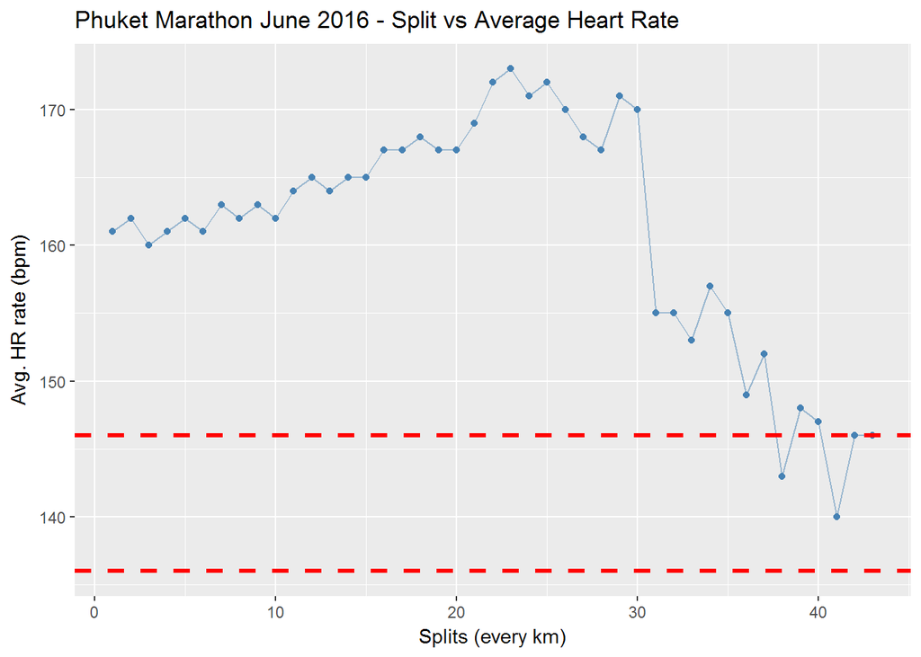

```r
ggplot(racedf, aes(x = as.numeric(Split), y = Avg.HR)) +
        geom_point(col = "steelblue") +
        geom_path(col = "steelblue", alpha = 0.5) +
        geom_hline(yintercept = c(136, 146), col = "red", lty = 2, lwd = 1.2) +
        labs(x = "Splits (every km)", y = "Avg. HR rate (bpm)") +
        ggtitle("Phuket Marathon June 2016 - Split vs Average Heart Rate")
```

The zone in between the two red lines is my aerobic zone where my body burns fat for fuel. Fat is a very economic resources for energy and is the primary source of fuel for the body in endurance sports.

Above this zone, the energy comes from carbohydrates (sugar) which are in limited supply. In addition, a lot of waste are being produced from this mechanism which lead to cramps and fatigue.

From this graph, we can clearly see that as the sugar is getting consumed, the heart rate increases until exhaustion of this source of fuel. At about 30km, the heart rate drops which coincide with the end of the running activity (see above for the average pace).

## Conclusion

In this brief analysis of my marathon race last year, we observed a phenomenon called “the Wall”. We also learn that sustainable long effort is not achieved at high heart rate.

Despite 8 months training for the event, I was clearly not prepared to face this challenge as my aerobic system was not fully developped to cope with the effort.

If you are interested to develop your aerobic system to burn fat for fuel, check out the Maffetone Method. https://philmaffetone.com/method/